# Презентация по лабораторной работе номер 4

Основы информационной безопасности

Татьяна Александровна Пономарева

Российский университет дружбы народов

2026-03-23

# Информация

## Докладчик

- Пономарева Татьяна Александровна
- Студент группы НКАбд-04-24
- Российский университет дружбы народов им. П. Лумумбы
- taponomareva6742@gmail.com
- https://github.com/taponomareva

# Вводная часть

## Цель работы

Получение практических навыков работы в консоли с расширенными атрибутами файлов.

## Задание

Определить расширенные атрибуты файла /home/guest/dir1/file1 от имени пользователя guest, установить на файл права 600, попытаться установить расширенный атрибут «a» от пользователя guest, зайти с правами администратора и установить атрибут «a» от имени суперпользователя, проверить правильность установки атрибута от пользователя guest, выполнить дозапись в файл слова «test» и прочитать его содержимое, попытаться удалить файл, стереть информацию (перезаписать), переименовать файл и изменить права командой chmod 000, снять расширенный атрибут «a» от имени суперпользователя, заменить атрибут «a» атрибутом «i», проверить возможность дозаписи.

## Теоретическое введение

Дискреционное управление доступом в ОС Linux обеспечивает возможность управления доступом к данным самими пользователями операционной системы, также оно применяется к каждому субъекту (пользователю) и сущности (файлу, каталогу).

Механизм дискреционного управления доступом именованных субъектов к именованным сущностям обеспечивает создание для каждой пары субъект-сущность явного и недвусмысленного перечисления разрешенных типов доступа, формирующих правила разграничения доступа (ПРД).

На защищаемые именованные сущности при их создании автоматически устанавливаются базовые дискреционные ПРД в виде:

- идентификаторов пользователя-владельца (UID) и группы-владельца (GID), которые вправе распоряжаться доступом к данной сущности;
- прав доступа данных субъектов к созданной сущности.

Сущностями доступа являются:файлы,каталоги, соединения (сокеты), сетевые пакеты, механизмы IPC (разделяемая память, очереди сообщений и др.) [1].

# Выполнение лабораторной работы

## Просмотр расширенных атрибутов файла, установка прав, установка атрибута “а”

Определяем расширенные атрибуты файла /home/guest/dir1/file1 от имени пользователя guest, устанавливаем на файл права 600, пытаемся установить расширенный атрибут «a» от пользователя guest, что не удается сделать, т к нет прав (рис. 1).

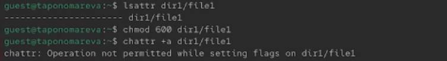

Рисунок 1: Просмотр расширенных атрибутов файла, установка прав, установка атрибута “а”

## Установка атрибута “а” от имени суперпользователя

Заходим с правами администратора и устанавливаем атрибут «a» от имени суперпользователя, проверяем правильность установки атрибута от пользователя guest, выполняем дозапись в файл слова «test» и читаем его содержимое (рис. 2).

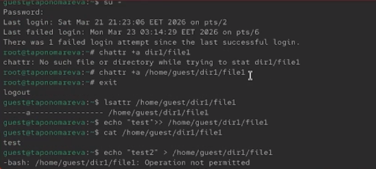

Рисунок 2: Установка атрибута “а” от имени суперпользователя

## Работа с атрибутом “а”

Пробуем удалить файл, стереть информацию (перезаписать), переименовать файл и изменить права командой chmod 000, снять расширенный атрибут «a» от имени суперпользователя (рис. 3).

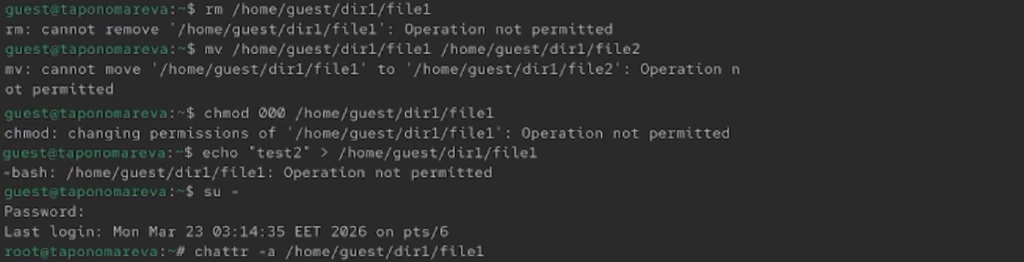

Рисунок 3: Работа с атрибутом “а”

## Работа с атрибутом “i”

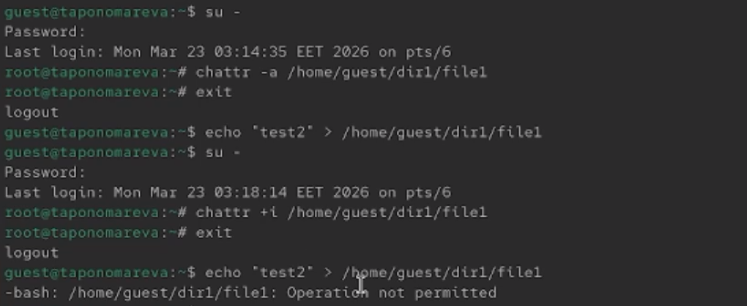

Рисунок 4: Работа с атрибутом “i”

# Выводы

В ходе проведения лабораторной работы были получены навыки работы в консоли с расширенными атрибутами файлов.

# Список литературы

[1] НПО РусБИТех. Дискреционное управление доступом (DAC): Документация по системе защиты информации операционной системы специального назначения «Astra Linux Special Edition» [Электронный ресурс]. Москва: НПО РусБИТех. URL: https://docs.astralinux.ru/latest/szi/szi/dac/ (дата обращения: 23.03.2026).